# Matplotlib Part 3. Object Oriented approach for Matplotlib

## Part 3. Object Oriented approach for Matplotlib

### Table of Contents

1. Object Oriented API in Matplotlib
2. Subplots
3. Plot Range
4. Axis Related Customization
5. Text Annotation

Let's start by importing the **pyploy** API from the **matplotlib** library. And **numpy** to create the data required to plot the graphs.

```python
import numpy as np

import matplotlib.pyplot as plt
%matplotlib inline
```

### 1. Object Oriented API in Matplotlib

**Why use the OOP API in Matplotlib ?** By using the Matplotlib's OOP API we can create a Figure instance and we can then start working on that figure. This will provide us with more flexible approach and this will make things way easier when we have lot of plots in the same canvas.

In simple words what we do here is that we create a **figure** object by using the method **plt.figure()** then using this **figure** we will call its **attributes** to achieve what we want.

1. Create `x` and `y` using `np.linspace`.
2. We will initiate a `figure` object by calling `plt.figure()`.
3. We will then add an `axis`.
4. We will then plot in this `axis` and set X-Label, Y-Label and Title.

```python
x = np.linspace(0, 10, 11)
y = x ** 2
```

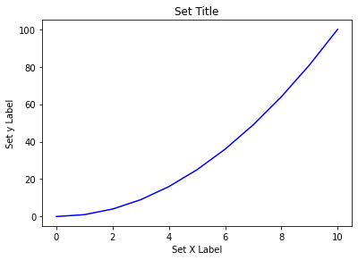

```python
fig = plt.figure()

# Position: Left(0.1), Bottom(0.1) and
# Size: Width(0.8), Height(0.8).
# The is range from 0 to 1.
axes = fig.add_axes([0.1, 0.1, 0.8, 0.8])

axes.plot(x, y, 'b')
axes.set_xlabel('Set X Label')
axes.set_ylabel('Set y Label')
axes.set_title('Set Title')

plt.show()
```

Let's look into plotting **one graph inside another one**. The process is similar to the one we have used above. The only thing we need to focus now is on the **Position** and **Size** of the **Second** Graph.

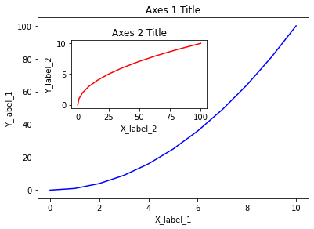

```python
fig = plt.figure()

axes1 = fig.add_axes([0.1, 0.1, 0.8, 0.8]) # First Axis
axes2 = fig.add_axes([0.2, 0.5, 0.4, 0.3]) # Second Axis

# First Axis
axes1.plot(x, y, 'b') # 'b' means blue color
axes1.set_xlabel('X_label_1')
axes1.set_ylabel('Y_label_1')
axes1.set_title('Axes 1 Title')

# Second Axis
axes2.plot(y, x, 'r') # 'r' means red color
axes2.set_xlabel('X_label_2')
axes2.set_ylabel('Y_label_2')
axes2.set_title('Axes 2 Title');

plt.show()
```

### 2. Subplots

1. We use the `plt.subplots()`, it will return 2 Objects -> `figure` and `axes`.
2. Then we will plot on the axes.

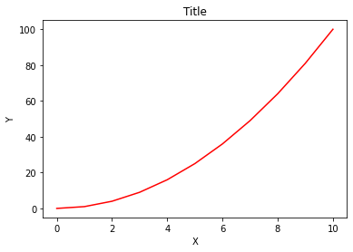

```python
fig, axes = plt.subplots()

axes.plot(x, y, 'r')
axes.set_xlabel('X')
axes.set_ylabel('Y')
axes.set_title('Title');

plt.show()
```

The above one was a simple example of `plt.subplots()`. It doesn't make much sense if we use it like we did in the above example.

Below is an example of what is the true purpose of using `plt.subplots()`. That is to create mutiple plots on the same canvas and then work on each of them with a better control over the figure.

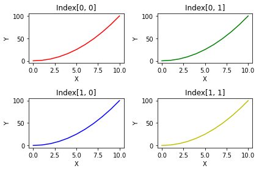

```python
fig, axes = plt.subplots(nrows=2, ncols=2)

# Top Left plot: Index[0, 0]
axes[0,0].plot(x, y, 'r')
axes[0,0].set_xlabel('X')
axes[0,0].set_ylabel('Y')
axes[0,0].set_title('Index[0, 0]');

# Top Right plot: Index[0, 1]
axes[0,1].plot(x, y, 'g')
axes[0,1].set_xlabel('X')
axes[0,1].set_ylabel('Y')
axes[0,1].set_title('Index[0, 1]');

# Top Right plot: Index[1, 0]
axes[1,0].plot(x, y, 'b')
axes[1,0].set_xlabel('X')
axes[1,0].set_ylabel('Y')
axes[1,0].set_title('Index[1, 0]');

# Top Right plot: Index[1, 1]
axes[1,1].plot(x, y, 'y')
axes[1,1].set_xlabel('X')
axes[1,1].set_ylabel('Y')
axes[1,1].set_title('Index[1, 1]');

plt.tight_layout()
plt.show()
```

I hope you understood how to use the `Indexing` and control each and every plot in the canvas the way you want it to be.

Indexing --> AXES[`row_number`, `column_number`]. As we all know in Python the indexing starts from 0.

### 3. Plot Range

There are times when plotting a graph from `0 to n` doesn't provide the perfect visualization that you are looking for. In that case we need to set the `X-Limit` and `Y-Limit`.

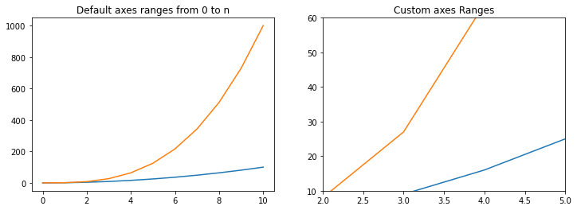

```python
fig, axes = plt.subplots(1, 2, figsize=(12, 4))

axes[0].plot(x, x**2, x, x**3)
axes[0].set_title("Default axes ranges from 0 to n")

axes[1].plot(x, x**2, x, x**3)
axes[1].set_ylim([10, 60])
axes[1].set_xlim([2, 5])
axes[1].set_title("Custom axes Ranges");

plt.show()
```

### 4. Axis Related Customization

1. Axis number and axis label spacing

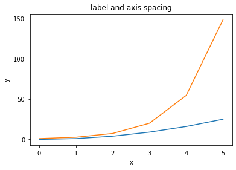

```python
import matplotlib

# This will set the distace between the x and y axis
# and the numbers on the axes.
matplotlib.rcParams['xtick.major.pad'] = 5
matplotlib.rcParams['ytick.major.pad'] = 5

z = np.array([0,1,2,3,4,5])

fig, ax = plt.subplots(1, 1)

ax.plot(z, z**2, z, np.exp(z))
ax.set_yticks([0, 50, 100, 150])

ax.set_title("label and axis spacing")

# padding between axis label and axis numbers
ax.xaxis.labelpad = 5
ax.yaxis.labelpad = 5

ax.set_xlabel("x")
ax.set_ylabel("y");
```

1. Axis position adjustments

Sometimes while saving the figures the plot gets cropped and to prevent that issue we need to adjust the position of the Axis.

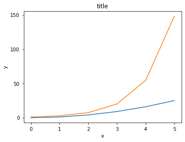

```python
fig, ax = plt.subplots(1, 1)

ax.plot(z, z**2, z, np.exp(z))
ax.set_yticks([0, 50, 100, 150])

ax.set_title("title")
ax.set_xlabel("x")
ax.set_ylabel("y")

fig.subplots_adjust(left=0.15, right=.9, bottom=0.1, top=0.9);
```

1. Axis grid

Axis grids helps in readability of the graph. We can toggle the axis grids on & off. We can also customize the grids based on our choice.

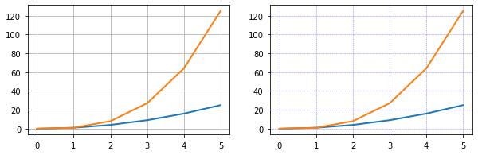

```python
fig, axes = plt.subplots(1, 2, figsize=(10,3))

# lw(parameter) --> line width

# Default Grid
axes[0].plot(z, z**2, z, z**3, lw=2)
axes[0].grid(True)

# Customized Grid
axes[1].plot(z, z**2, z, z**3, lw=2)
axes[1].grid(color='b', alpha=0.5, linestyle='dashed', linewidth=0.5)
```

1. Axis Spines

As we can see that the plot has 4 borders `x, y and the 2 other opposite sides`. Sometimes we don't need the other 2 sides. In that case we can remove the `Axis Spines`.

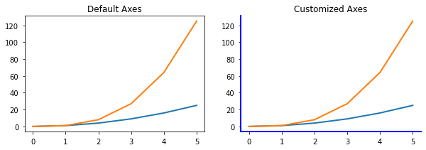

```python
fig, axes = plt.subplots(1, 2, figsize=(10,3))

# Default Axes
axes[0].plot(z, z**2, z, z**3, lw=2)
axes[0].set_title("Default Axes")


# Customized Axes
axes[1].plot(z, z**2, z, z**3, lw=2)
axes[1].set_title("Customized Axes")

# Removing Top and Right Spines
axes[1].spines['right'].set_visible(False)
axes[1].spines['top'].set_visible(False)

# Setting Left and Bottom Spines to Blue Color
# And Setting Linewidtht to 2
axes[1].spines['left'].set_color('blue')
axes[1].spines['bottom'].set_color('blue')
axes[1].spines['left'].set_linewidth(2)
axes[1].spines['bottom'].set_linewidth(2)

plt.show()
```

1. Twin Axes

Sometimes it is useful to have dual x or y axes in a figure; for example, when plotting curves with different units together. Matplotlib supports this with the `twinx` and `twiny` functions:

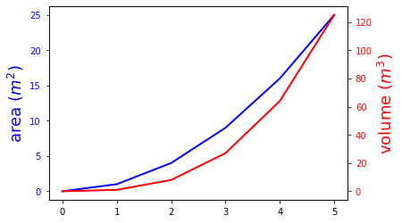

```python
fig, ax1 = plt.subplots()

ax1.plot(z, z**2, lw=2, color="blue")
ax1.set_ylabel(r"area $(m^2)$", fontsize=18, color="blue")

for label in ax1.get_yticklabels():
    label.set_color("blue")

ax2 = ax1.twinx()
ax2.plot(z, z**3, lw=2, color="red")
ax2.set_ylabel(r"volume $(m^3)$", fontsize=18, color="red")

for label in ax2.get_yticklabels():
    label.set_color("red")
```

### 5. Text annotation

Having text written on the graphs that points at certain cordinates, area under the graph or line equations etc helps a lot in understanding the graph.

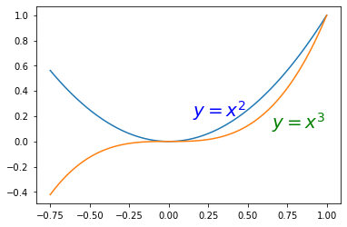

```python
z = np.linspace(-0.75, 1., 100)

fig, ax = plt.subplots()

ax.plot(z, z**2, z, z**3)

ax.text(0.15, 0.2, r"$y=x^2$", fontsize=20, color="blue")
ax.text(0.65, 0.1, r"$y=x^3$", fontsize=20, color="green");
```